# Mapping the Mosaic of Vulnerability: A Multi-Source Assessment of Wisconsin’s Ecological Stress

FWE 711 Final Project

Jacob Johnson

## Introduction

Ecosystems don’t respond to stress uniformly. Why are some landscapes resilient while neighbors collapse?

To understand how *vulnerable* a given location may be to climate stress, we need to understand the baseline environmental conditions conditions as well as the stress on that location.

#### Research Question

How do long-term environmental baselines interact with climate hazards to drive distinct modes of ecological vulnerability?

#### Project Outline

- PCA on environmental baselines
- Factor Analysis on climate stress variables
- Clustering on combined latent variables

## Data

Data was collected via Google Earth Engine<sup>1</sup> at 1713 locations across Wisconsin.

### Stress Variables

From summer 2021.

Variables for Evaluating Ecological Stress

| NDVI_mean |
| --- |
| NDWI_mean |
| GPP_mean |
| Percent_NonVegetated |
| LST_mean |
| LST_sd |

### Baseline Variables

Aggregated from 2011-2020.

Baseline Environmental Variables

| Elevation |
| --- |
| Slope |
| Aspect |
| SoilClay_b10 |
| SoilWaterCap_b10 |
| MaxTemp_mean |
| MaxTemp_sd |
| MinTemp_min |
| MinTemp_sd |
| Precip_mean |
| SWE_max |
| SurfaceRad_mean |
| VaporPressure_mean |

### Data Locations

[figure not shown]

[^1]: https://earthengine.google.com/faq/

## Data

[figure not shown]

# Part 1: PCA for Baseline Environmental Variables

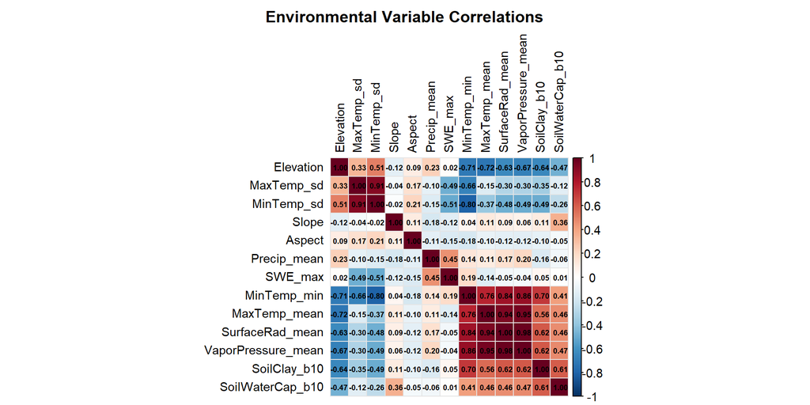

## PCA Results

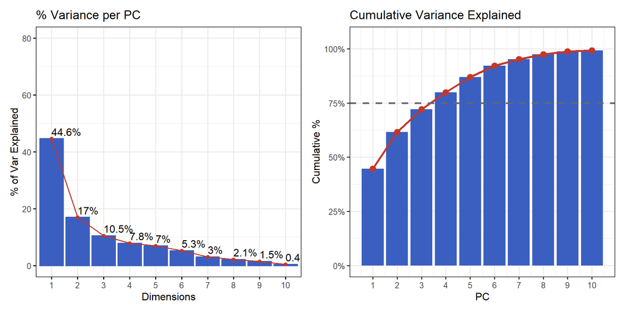

## PCA Results

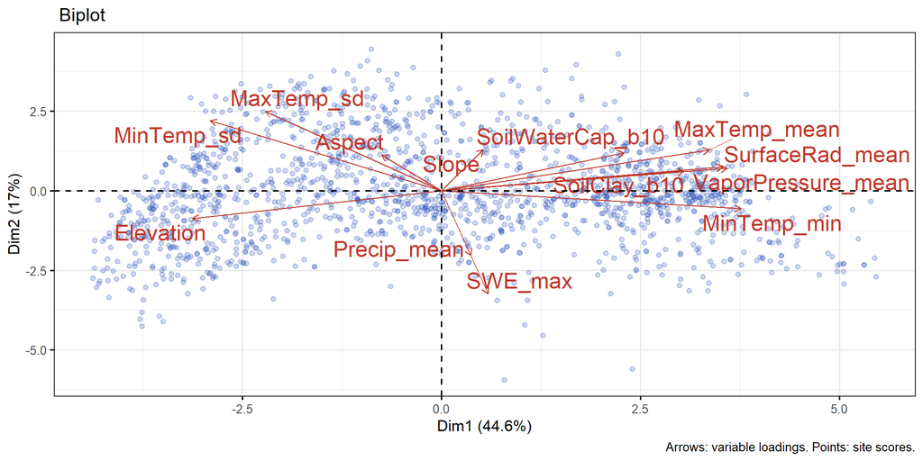

## PCA Results

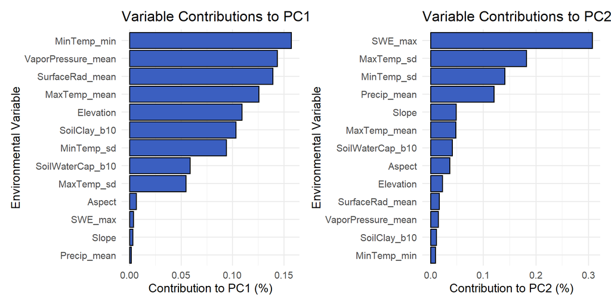

## PCA Results

[figure not shown]

# Part 2: Factor Analysis for Stress Variables

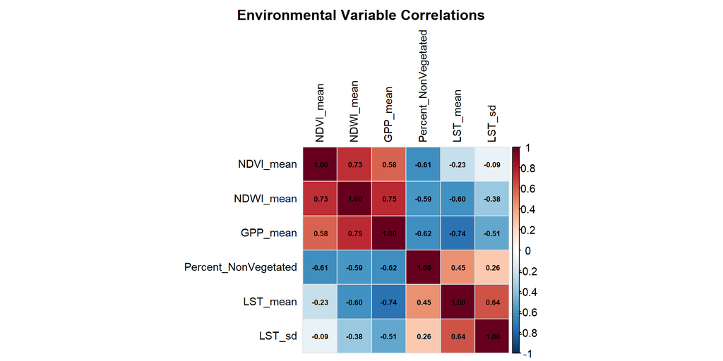

## EFA

First, I test to see if factor analysis is reasonable on this data.

```
Kaiser-Meyer-Olkin factor adequacy
Call: KMO(r = stress_vars)
Overall MSA =  0.77
MSA for each item =
           NDVI_mean            NDWI_mean             GPP_mean
                0.63                 0.79                 0.84
Percent_NonVegetated             LST_mean               LST_sd
                0.89                 0.70                 0.85
```

I then perform EFA on a subset of my sampled locations to get an idea of the factor structure.

```
Parallel analysis suggests that the number of factors =  2  and the number of components =  NA
```

```
Loadings:
                     ML2    ML1
NDVI_mean                    1.032
NDWI_mean            -0.358  0.642
GPP_mean             -0.705  0.338
Percent_NonVegetated        -0.531
LST_mean              0.929
LST_sd                0.733

                 ML2   ML1
SS loadings    2.114 1.890
Proportion Var 0.352 0.315
Cumulative Var 0.352 0.667
```

## EFA

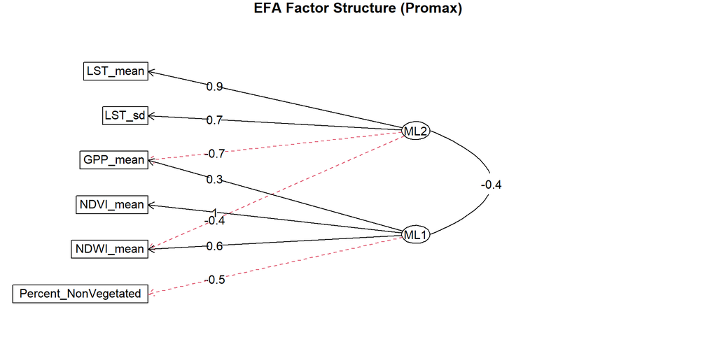

## CFA

Now, with this structure in mind, I fit a CFA with all the data. This will allow me to set some factor loadings to zero and get a more theoretical model.

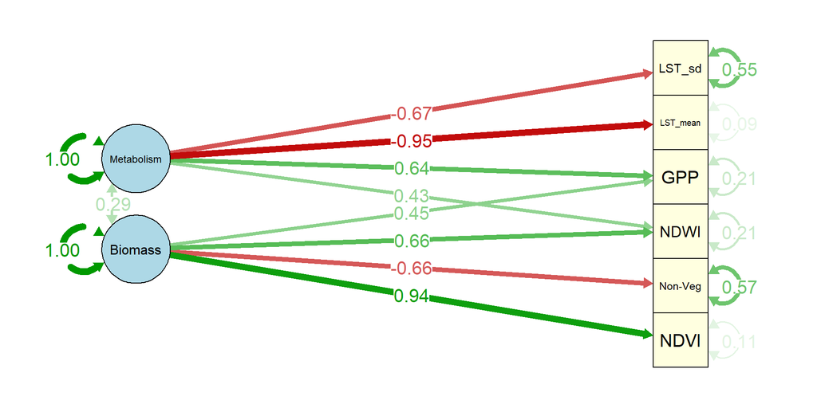

We can then extract the latent scores of both Biomass and Metabolism for each location.

# Part 3: Clustering to identify modes of vulnerability

We can now combine the Principal Components from Part 1 and the predicted latent variables from Part 2 to get a full data set that includes both baseline climate information and how each location responds to climate stress. Then, we can use clustering to group locations based on how they are currently, and how they are reacting.

## K-Means Clustering

We first rescale the Principal Components and Latent Vulnerability scores so that they are not imbalanced in our clustering.

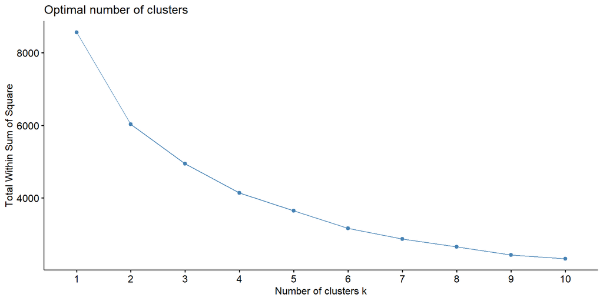

## Using 4 Clusters

[figure not shown]

## Using 4 Clusters

| Cluster | N | Mean_Biomass | Mean_Metabolism | Mean_PC1 | Mean_PC2 | Mean_PC3 |
| --- | --- | --- | --- | --- | --- | --- |
| 1 | 613 | 0.5877460 | 0.9004433 | -2.2093600 | -0.8458034 | 0.0155320 |
| 2 | 583 | -0.5131367 | -0.8340015 | 2.3878226 | -0.4574980 | 0.2561961 |
| 3 | 474 | 0.1439002 | -0.2903925 | -0.2349941 | 1.7770275 | -0.0319819 |
| 4 | 43 | -3.0078686 | 1.6720271 | 1.7121933 | -1.3281919 | -3.3424198 |

## Conclusions

1. Used PCA to find a suitable baseline from lots of available data.
2. Separated ecosystem potential (Biomass) from performance (Metabolism).
3. Clustered locations into groups with other similar locations

### Limitations

1. Just looked at summer 2021.
2. Didn’t do anything about spatial correlation in my variables.
3. Could look at a representative location for each cluster instead of the mean.